# Analysis

dillonchewwx

14/02/2021

# Load data according to instructions in assignment

```r
#install.packages("devtools")
#devtools::install_github("jhudsl/collegeIncome")
library(collegeIncome)
data(college)
```

Download and install the matahari R package:

```r
#devtools::install_github("jhudsl/matahari")
library(matahari)
```

Document analysis:

```r
dance_start(value = FALSE, contents = FALSE)
```

# Explore the dataset

```r
dim(college)
```

```
## [1] 173  19
```

```r
names(college)
```

```
##  [1] "rank"                             "major_code"
##  [3] "major"                            "major_category"
##  [5] "total"                            "sample_size"
##  [7] "perc_women"                       "p25th"
##  [9] "median"                           "p75th"
## [11] "perc_men"                         "perc_employed"
## [13] "perc_employed_fulltime"           "perc_employed_parttime"
## [15] "perc_employed_fulltime_yearround" "perc_unemployed"
## [17] "perc_college_jobs"                "perc_non_college_jobs"
## [19] "perc_low_wage_jobs"
```

```r
head(college)
```

```
##   rank major_code                                     major major_category
## 1    1       2419                     Petroleum Engineering    Engineering
## 2    2       2416            Mining And Mineral Engineering    Engineering
## 3    3       2415                 Metallurgical Engineering    Engineering
## 4    4       2417 Naval Architecture And Marine Engineering    Engineering
## 5    5       2405                      Chemical Engineering    Engineering
## 6    6       2418                       Nuclear Engineering    Engineering
##   total sample_size perc_women p25th median  p75th   perc_men perc_employed
## 1  2339          36  0.9109326 25000  40000  50000 0.08906743     0.9115044
## 2   756           7  0.5154064 26000  37000  40000 0.48459355     0.7980501
## 3   856           3  0.5942076 26700  45000  60000 0.40579235     0.7871943
## 4  1258          16  0.6521298 26000  35000  45000 0.34787018     0.8465608
## 5 32260         289  0.4179248 31500  62000 109000 0.58207520     0.8515625
## 6  2573          17  0.4305368 23000  44700  50000 0.56946324     0.8474507
##   perc_employed_fulltime perc_employed_parttime
```

[output cut: 20 more lines]

```r
table(college$major_category)
```

```
##
##     Agriculture & Natural Resources                                Arts
##                                  10                                   8
##              Biology & Life Science                            Business
##                                  14                                  13
##         Communications & Journalism             Computers & Mathematics
##                                   4                                  11
##                           Education                         Engineering
##                                  16                                  29
##                              Health           Humanities & Liberal Arts
##                                  12                                  15
## Industrial Arts & Consumer Services                   Interdisciplinary
##                                   7                                   1
##                 Law & Public Policy                   Physical Sciences
##                                   5                                  10
##            Psychology & Social Work                      Social Science
##                                   9                                   9
```

We note that there are 19 variables which correspond to those in the codebook. Considering that we are only interested in understanding the association between major category and income, we will only require the following variables:

- major_category (self-explanatory)
- median (median earnings)
- p25th (25% percentile)
- p75th (75% percentile)

We also note that there is only one major which falls under the Interdisciplinary category and thus we will remove it from the data set. We will obtain a quick summary of the variables using dplyr.

```r
library(tidyverse)
college_filt<-college %>%
    select(major_category, median, p25th, p75th) %>%
    filter(major_category!="Interdisciplinary") %>%
    group_by(major_category) %>%
    summarize(Median=mean(median), p25th=mean(p25th), p75th=mean(p75th)) %>%
    arrange(Median)
college_filt
```

```
## # A tibble: 15 x 4
##    major_category                      Median  p25th  p75th
##    <chr>                                <dbl>  <dbl>  <dbl>
##  1 Computers & Mathematics             34718. 26545. 44455.
##  2 Humanities & Liberal Arts           35167. 25967. 46133.
##  3 Law & Public Policy                 37800  27600  49400
##  4 Education                           37938. 25616. 52375
##  5 Arts                                38050  28775  45262.
##  6 Social Science                      39067. 28956. 52556.
##  7 Psychology & Social Work            39889. 31067. 50889.
##  8 Health                              40317. 28917. 50750
##  9 Engineering                         40393. 28662. 53379.
## 10 Physical Sciences                   40400  31280  50900
## 11 Industrial Arts & Consumer Services 40429. 30429. 51029.
## 12 Communications & Journalism         42000  34000  50000
## 13 Agriculture & Natural Resources     43500  30300  53600
## 14 Biology & Life Science              43864. 32457. 56214.
## 15 Business                            49154. 37208. 58862.
```

Lets do a plot to see the relationship between the median earnings and the major category.

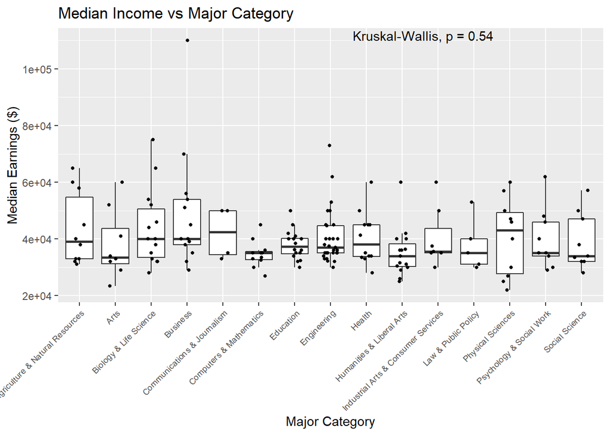

```r
library(ggpubr)
ggplot(college %>% filter(major_category!="Interdisciplinary"), aes(x=major_category, y=median)) +
    geom_boxplot(outlier.shape = NA) +
    geom_jitter(height=0, width=0.2, size=1) +
    theme(axis.text.x = element_text(angle=45, size=7, hjust=1, vjust=1)) +
    labs(x="Major Category", y="Median Earnings ($)", title="Median Income vs Major Category") +
    stat_compare_means(label.x.npc=0.6)
```

Repeat for 25th percentile.

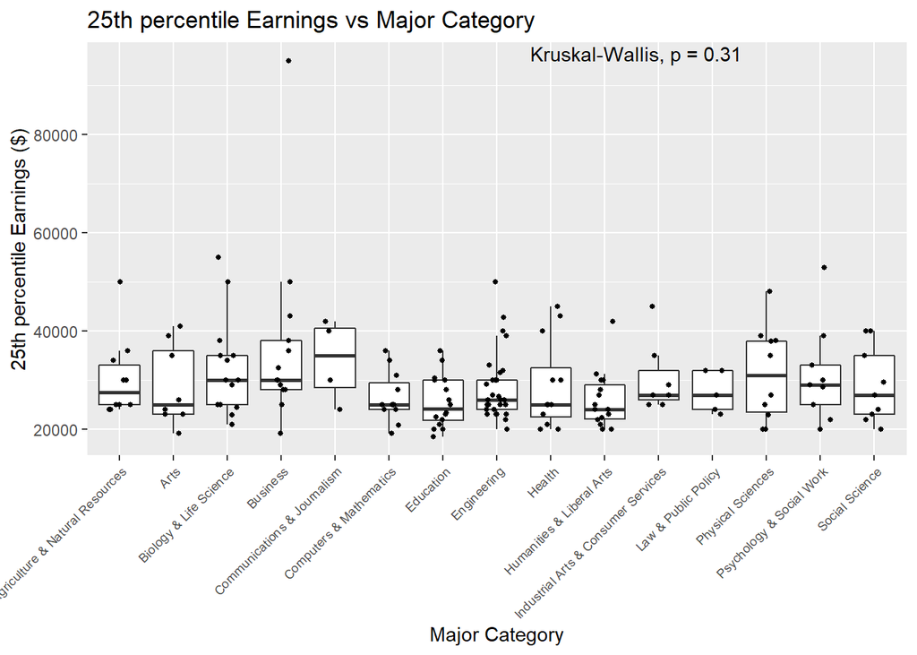

```r
ggplot(college %>% filter(major_category!="Interdisciplinary"), aes(x=major_category, y=p25th)) +
    geom_boxplot(outlier.shape = NA) +
    geom_jitter(height=0, width=0.2, size=1) +
    theme(axis.text.x = element_text(angle=45, size=7, hjust=1, vjust=1)) +
    labs(x="Major Category", y="25th percentile Earnings ($)", title="25th percentile Earnings vs Major Category") +
    stat_compare_means(label.x.npc=0.6)
```

Repeat for 75th percentile.

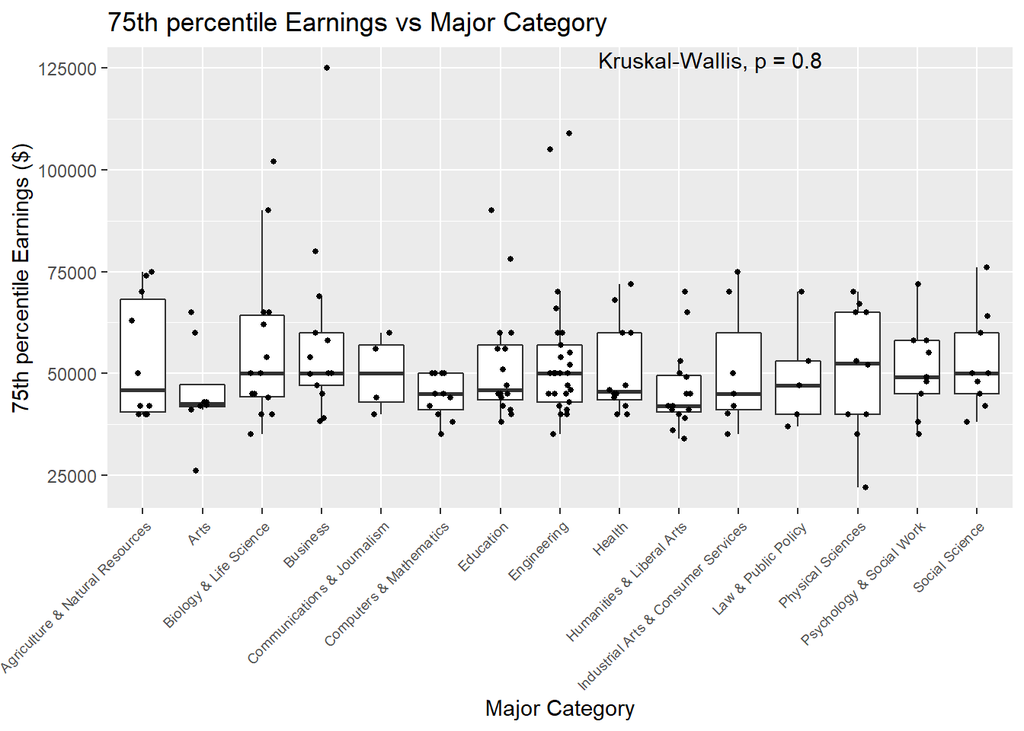

```r
ggplot(college %>% filter(major_category!="Interdisciplinary"), aes(x=major_category, y=p75th)) +
    geom_boxplot(outlier.shape = NA) +
    geom_jitter(height=0, width=0.2, size=1) +
    theme(axis.text.x = element_text(angle=45, size=7, hjust=1, vjust=1)) +
    labs(x="Major Category", y="75th percentile Earnings ($)", title="75th percentile Earnings vs Major Category") +
    stat_compare_means(label.x.npc=0.6)
```

Based on the graphs, there isn’t much variation across the different major categories for the median, 25th and 75th percentiles. In fact, statistical tests (Kruskal-Wallis) would suggest that the medians are the same for all groups.

# Linear Regression Analysis

We will attempt to perform a linear fit with the major category as the predictor variable, and median earning as the outcome variable.

```r
fit<-lm(median~major_category, college %>% filter(major_category!="Interdisciplinary"))
summary(fit)$coef
```

```
##                                                     Estimate Std. Error
## (Intercept)                                       43500.0000   3590.819
## major_categoryArts                                -5450.0000   5386.228
## major_categoryBiology & Life Science                364.2857   4701.486
## major_categoryBusiness                             5653.8462   4776.236
## major_categoryCommunications & Journalism         -1500.0000   6717.807
## major_categoryComputers & Mathematics             -8781.8182   4961.429
## major_categoryEducation                           -5562.5000   4577.414
## major_categoryEngineering                         -3106.8966   4164.154
## major_categoryHealth                              -3183.3333   4861.992
## major_categoryHumanities & Liberal Arts           -8333.3333   4635.727
## major_categoryIndustrial Arts & Consumer Services -3071.4286   5595.887
## major_categoryLaw & Public Policy                 -5700.0000   6219.481
## major_categoryPhysical Sciences                   -3100.0000   5078.185
## major_categoryPsychology & Social Work            -3611.1111   5217.339
## major_categorySocial Science                      -4433.3333   5217.339
##                                                       t value     Pr(>|t|)
## (Intercept)                                       12.11422804 2.873928e-24
## major_categoryArts                                -1.01183974 3.131715e-01
## major_categoryBiology & Life Science               0.07748311 9.383379e-01
## major_categoryBusiness                             1.18374520 2.383031e-01
## major_categoryCommunications & Journalism         -0.22328715 8.236023e-01
## major_categoryComputers & Mathematics             -1.77001776 7.866520e-02
## major_categoryEducation                           -1.21520579 2.261119e-01
## major_categoryEngineering                         -0.74610504 4.567197e-01
## major_categoryHealth                              -0.65473851 5.135942e-01
## major_categoryHumanities & Liberal Arts           -1.79763232 7.415704e-02
## major_categoryIndustrial Arts & Consumer Services -0.54887249 5.838727e-01
## major_categoryLaw & Public Policy                 -0.91647520 3.608233e-01
## major_categoryPhysical Sciences                   -0.61045434 5.424435e-01
## major_categoryPsychology & Social Work            -0.69213657 4.898739e-01
## major_categorySocial Science                      -0.84973074 3.967687e-01
```

From this analysis, the mean of the first category, Agriculture & Natural Resources is used as the reference. Here, we see that the estimate is negative for all categories except for Biology & Life Science, and Business, suggesting higher means in median income as compared to the reference category. Looking at the p-values, as all are > 0.05, they are all not significant and thus suggesting that the means of the other categories with reference to the Agriculture & Natural Resource major are the same.

We can repeat this analysis for all 15 categories to find if there are any significantly different major categories which will affects the median income.

```r
college$major_category<-factor(college$major_category)
college<-college[order(college$major_category),]
college<-filter(college, major_category!="Interdisciplinary")
mat<-matrix(nrow=15, ncol=15)
colnames(mat)<-unique(college$major_category)
rownames(mat)<-unique(college$major_category)
for (i in 1:15){
    ref_major_category<-relevel(college$major_category, as.character(unique(college$major_category))[i])
    fit<-lm(median~ref_major_category, college)
    temp<-summary(fit)$coef[,4]
    temp[c(1,i)]<-temp[c(i,1)]
    mat[,i]<-temp
}
head(mat)
```

```
##                                 Agriculture & Natural Resources         Arts
## Agriculture & Natural Resources                    2.873928e-24 3.131715e-01
## Arts                                               3.131715e-01 3.919976e-17
## Biology & Life Science                             9.383379e-01 2.497166e-01
## Business                                           2.383031e-01 3.103954e-02
## Communications & Journalism                        8.236023e-01 5.708113e-01
## Computers & Mathematics                            7.866520e-02 5.286520e-01
##                                 Biology & Life Science     Business
## Agriculture & Natural Resources           2.497166e-01 2.283166e-01
## Arts                                      9.383379e-01 2.383031e-01
## Biology & Life Science                    1.191360e-30 3.103954e-02
## Business                                  2.283166e-01 9.444322e-34
## Communications & Journalism               7.725155e-01 2.722123e-01
## Computers & Mathematics                   4.732392e-02 2.271210e-03
##                                 Communications & Journalism
## Agriculture & Natural Resources                2.722123e-01
## Arts                                           8.236023e-01
## Biology & Life Science                         5.708113e-01
## Business                                       7.725155e-01
## Communications & Journalism                    7.850192e-12
## Computers & Mathematics                        2.737483e-01
##                                 Computers & Mathematics   Education Engineering
## Agriculture & Natural Resources            2.737483e-01 0.470238818  0.48844993
## Arts                                       7.866520e-02 0.226111913  0.45671966
## Biology & Life Science                     5.286520e-01 0.981774949  0.60609050
## Business                                   4.732392e-02 0.155787839  0.34901032
## Communications & Journalism                2.271210e-03 0.008989341  0.02210557
## Computers & Mathematics                    6.691567e-19 0.523110359  0.79111268
##                                    Health Humanities & Liberal Arts
## Agriculture & Natural Resources 0.9843783               0.243360905
## Arts                            0.5135942               0.074157042
## Biology & Life Science          0.6624690               0.562746013
## Business                        0.4282974               0.040934409
## Communications & Journalism     0.0536745               0.001408831
## Computers & Mathematics         0.7976957               0.286533364
##                                 Industrial Arts & Consumer Services
## Agriculture & Natural Resources                           0.3129260
## Arts                                                      0.5838727
## Biology & Life Science                                    0.6862230
## Business                                                  0.5143113
## Communications & Journalism                               0.1032059
## Computers & Mathematics                                   0.8255411
##                                 Law & Public Policy Physical Sciences
## Agriculture & Natural Resources          0.69312935        0.67648812
## Arts                                     0.36082332        0.54244355
## Biology & Life Science                   0.96924295        0.66322000
## Business                                 0.30690158        0.46231376
## Communications & Journalism              0.05925698        0.06872781
## Computers & Mathematics                  0.58215837        0.81205752
##                                 Psychology & Social Work Social Science
## Agriculture & Natural Resources               0.92208588     0.87811940
## Arts                                          0.48987394     0.39676871
## Biology & Life Science                        0.73937077     0.85404867
## Business                                      0.41378710     0.32423231
## Communications & Journalism                   0.06173891     0.04216615
## Computers & Mathematics                       0.75744004     0.66787220
```

The matrix mat shows all the p-values for each reference categories. From this matrix, we can identify which categories are significantly different, and we can visualize this using a heatmap. We note that the diagonal values are all very close to zero.

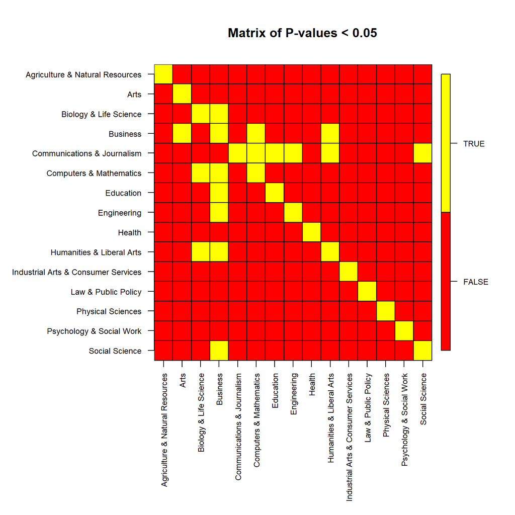

```r
library(plot.matrix)
par(mar=c(12,12,5,5))
plot(mat<0.05, las=2, main="Matrix of P-values < 0.05", cex.axis=0.75, xlab="", ylab="")
```

There are also significant differences between **Communications & Journalism** with:

- Computers & Mathematics
- Education
- Engineering
- Humanities and Liberal Arts
- Social Science

However in general, we do not observe too much difference between the other major categories on the effect of median income.

Before finishing up, lets check the residuals to verify our assumptions for linear regression.

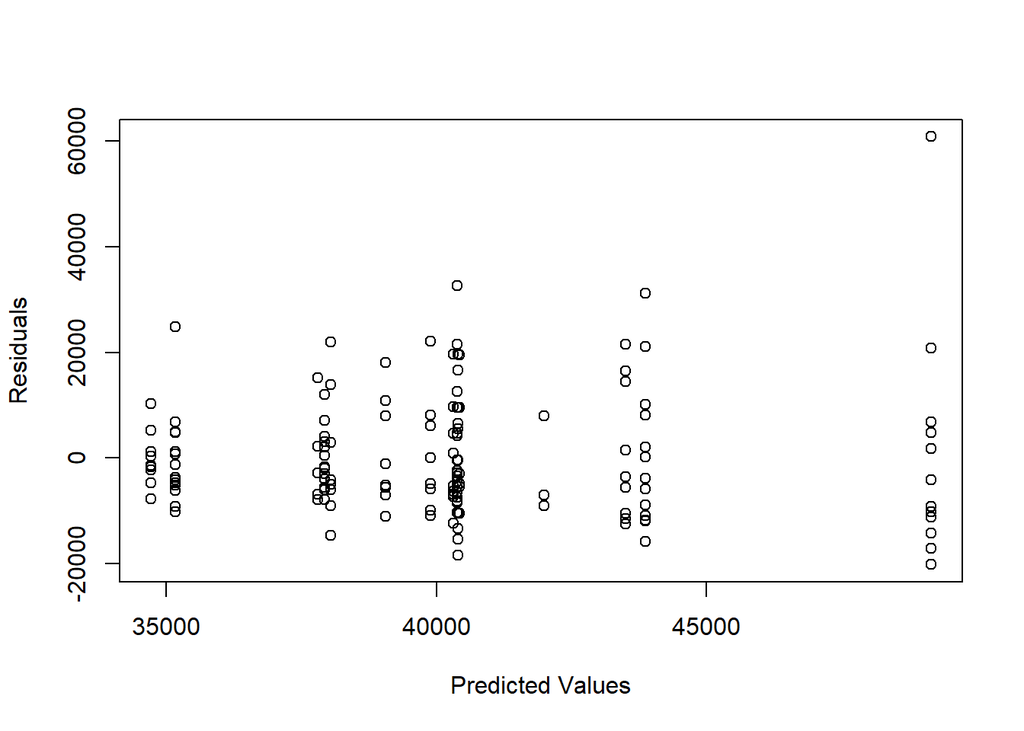

```r
plot(fitted.values(fit), residuals(fit), xlab="Predicted Values", ylab="Residuals")
```

There doesn’t seem to be any clear pattern and all the values cluster around 0.

Save the documentation.

```r
dance_save("college_major_analysis.rds")
```